# Machine Learning - Course Project

Massimo Di Michele

12/23/2016

## Abstract

The object of this analysis is to build a model to predict “how well” barbell weights lifting exercises are performed. To begin with, we load the data and the required packages.

```r
if(!file.exists("pml-training.csv")) {
        fileURL = "https://d396qusza40orc.cloudfront.net/predmachlearn/pml-training.csv"
        download.file(fileURL, destfile = "pml-training.csv", method = "auto")
}

tr.data = read.csv("pml-training.csv")

library(caret)
library(ggplot2)
library(rattle)
library(forecast)
set.seed(233)
```

## Cleaning the data

Secondly, we clean data. We start by removing certain variables (such as date, time and name of subject performing the exercise) from the dataset. This operation is limited to the first 7 columns of the dataset. We also convert all variables to numeric and remove columns containing NAs. Arbitrarily removing data is never a good thing; however, certain machine learning algorithms cannot handle NAs and ignore the affected records. The affected variables do show proper values about 2% of the times (i.e. when the window is reset), so populating NAs based on existing data would inevitably distort the information and is not a recommendable procedure in this instance.

```r
length(unique(tr.data$skewness_roll_belt)) / length(tr.data$skewness_roll_belt)
```

```
## [1] 0.02013047
```

```r
tr.data.red = tr.data[,-c(1:7,160)]
indx = sapply(tr.data.red, is.factor)
tr.data.red[indx] = lapply(tr.data.red[indx], function(x) as.numeric(as.character(x)))
indx = sapply(tr.data.red, function(x) sum(is.na(x)) > 5000)
tr.data.red = tr.data.red[, !indx]
classe = tr.data$classe
tr.data.red = cbind(classe, tr.data.red)
```

Now let’s perform a non-zero variance test to make sure that all variables at our disposal are significant and we do not need to filter out any further, at least at this preliminary stage.

```r
nearZeroVar(tr.data.red, saveMetrics = TRUE)
```

```
##                      freqRatio percentUnique zeroVar   nzv
## classe                1.469581     0.0254816   FALSE FALSE
## roll_belt             1.101904     6.7781062   FALSE FALSE
## pitch_belt            1.036082     9.3772296   FALSE FALSE
## yaw_belt              1.058480     9.9734991   FALSE FALSE
## total_accel_belt      1.063160     0.1477933   FALSE FALSE
## gyros_belt_x          1.058651     0.7134849   FALSE FALSE
## gyros_belt_y          1.144000     0.3516461   FALSE FALSE
## gyros_belt_z          1.066214     0.8612782   FALSE FALSE
## accel_belt_x          1.055412     0.8357966   FALSE FALSE
## accel_belt_y          1.113725     0.7287738   FALSE FALSE
## accel_belt_z          1.078767     1.5237998   FALSE FALSE
## magnet_belt_x         1.090141     1.6664968   FALSE FALSE
## magnet_belt_y         1.099688     1.5187035   FALSE FALSE
## magnet_belt_z         1.006369     2.3290184   FALSE FALSE
## roll_arm             52.338462    13.5256345   FALSE FALSE
## pitch_arm            87.256410    15.7323412   FALSE FALSE
## yaw_arm              33.029126    14.6570176   FALSE FALSE
## total_accel_arm       1.024526     0.3363572   FALSE FALSE
## gyros_arm_x           1.015504     3.2769341   FALSE FALSE
## gyros_arm_y           1.454369     1.9162165   FALSE FALSE
## gyros_arm_z           1.110687     1.2638875   FALSE FALSE
## accel_arm_x           1.017341     3.9598410   FALSE FALSE
## accel_arm_y           1.140187     2.7367241   FALSE FALSE
## accel_arm_z           1.128000     4.0362858   FALSE FALSE
## magnet_arm_x          1.000000     6.8239731   FALSE FALSE
## magnet_arm_y          1.056818     4.4439914   FALSE FALSE
## magnet_arm_z          1.036364     6.4468454   FALSE FALSE
## roll_dumbbell         1.022388    84.2065029   FALSE FALSE
## pitch_dumbbell        2.277372    81.7449801   FALSE FALSE
## yaw_dumbbell          1.132231    83.4828254   FALSE FALSE
## total_accel_dumbbell  1.072634     0.2191418   FALSE FALSE
## gyros_dumbbell_x      1.003268     1.2282132   FALSE FALSE
## gyros_dumbbell_y      1.264957     1.4167771   FALSE FALSE
## gyros_dumbbell_z      1.060100     1.0498420   FALSE FALSE
## accel_dumbbell_x      1.018018     2.1659362   FALSE FALSE
## accel_dumbbell_y      1.053061     2.3748853   FALSE FALSE
## accel_dumbbell_z      1.133333     2.0894914   FALSE FALSE
## magnet_dumbbell_x     1.098266     5.7486495   FALSE FALSE
## magnet_dumbbell_y     1.197740     4.3012945   FALSE FALSE
## magnet_dumbbell_z     1.020833     3.4451126   FALSE FALSE
## roll_forearm         11.589286    11.0895933   FALSE FALSE
## pitch_forearm        65.983051    14.8557741   FALSE FALSE
## yaw_forearm          15.322835    10.1467740   FALSE FALSE
## total_accel_forearm   1.128928     0.3567424   FALSE FALSE
## gyros_forearm_x       1.059273     1.5187035   FALSE FALSE
## gyros_forearm_y       1.036554     3.7763735   FALSE FALSE
## gyros_forearm_z       1.122917     1.5645704   FALSE FALSE
## accel_forearm_x       1.126437     4.0464784   FALSE FALSE
## accel_forearm_y       1.059406     5.1116094   FALSE FALSE
## accel_forearm_z       1.006250     2.9558659   FALSE FALSE
## magnet_forearm_x      1.012346     7.7667924   FALSE FALSE
## magnet_forearm_y      1.246914     9.5403119   FALSE FALSE
## magnet_forearm_z      1.000000     8.5771073   FALSE FALSE
```

All variables are non-zero. There is a further step to perform, functional to our model building and essential to ensure proper cross-validation. The data do not appear to be in random order. In fact, a quick look at the original dataset shows that the records are ordered by subject performing the exercise and time. Using K-fold cross validation (as we will) and randomizing the records ensures proper cross-validation.

```r
tr.data.red = tr.data.red[sample(nrow(tr.data.red)),]
```

Finally, we add a short chunk of code to optimize computing power as we will deal with computationally intensive calculations in the following.

```r
library(parallel)
library(doParallel)
cluster <- makeCluster(detectCores() - 1) # convention to leave 1 core for OS
registerDoParallel(cluster)
```

## Building the model

The outcomes are classified in 5 categories. A prediction tree approach looks suitable to address the matter at hand. We always use K-fold cross-validation in the models built in this section, with the exception of the random forests model where the sampling performed by the algorithm at each noted performs cross-validation inherently. (train control is still part of the parameters as it specifies how random forests samples data.)

```r
train.control <- trainControl(method="cv", number=5, savePredictions = TRUE, allowParallel = TRUE)
```

```r
rpartMod = train(classe ~ ., method = "rpart",  data = tr.data.red, trControl = train.control)
```

```r
rpartMod
```

[output not shown]

[figure not shown]

```r
fancyRpartPlot(rpartMod$finalModel)
```

Unfortunately the algorithm seems to be accurate about 50% of the time, a very low score. Also in the graphic representation we can witness the prediction error. This means that adopting an algorithm whereby we split based on a variable at the time does not yield a good prediction. We should consider a set of variables in aggregate for each node in order to improve our estimates. How we determine the variables to choose? To address these points we try a random forests approach next, which is really demanding on the machine and requires some time to run.

```r
rfMod = train(classe ~ ., method = "rf", data = tr.data.red, trControl = train.control, prox = TRUE)
```

```r
rfMod$finalModel
```

```
##
## Call:
##  randomForest(x = x, y = y, mtry = param$mtry, proximity = TRUE)
##                Type of random forest: classification
##                      Number of trees: 500
## No. of variables tried at each split: 27
##
##         OOB estimate of  error rate: 0.45%
## Confusion matrix:
##      A    B    C    D    E  class.error
## A 5575    3    1    0    1 0.0008960573
## B   18 3773    6    0    0 0.0063207796
## C    0   10 3403    9    0 0.0055523086
## D    0    1   26 3186    3 0.0093283582
## E    0    1    4    5 3597 0.0027723870
```

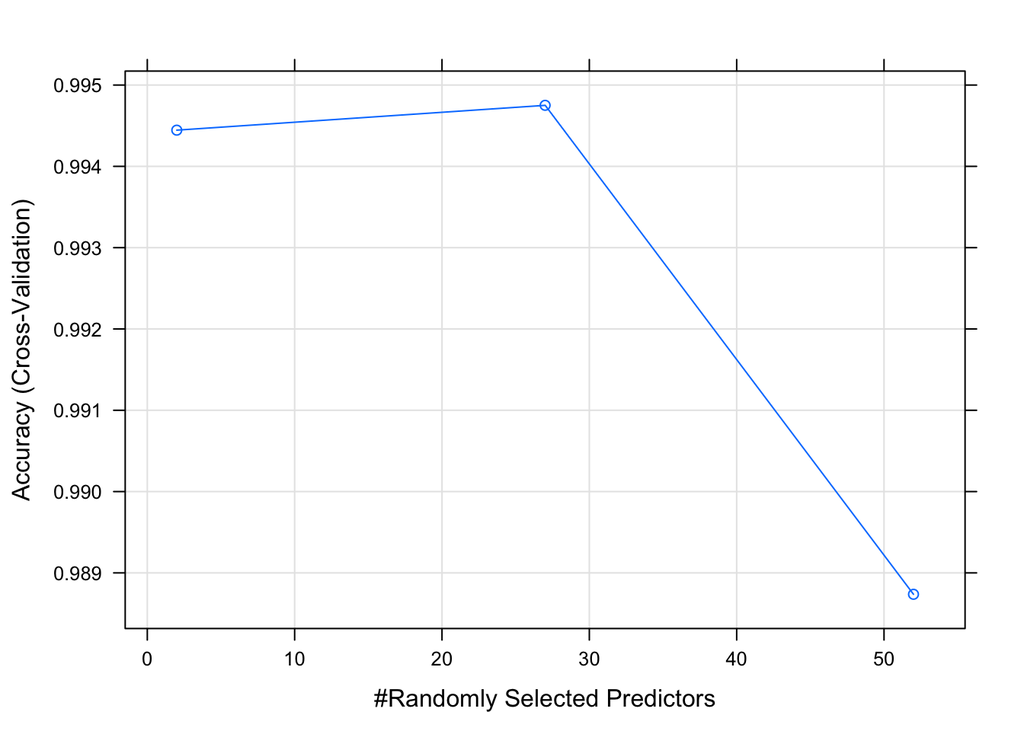

```r
plot(rfMod)
```

The accuracy has increased to a level close to 100%, meaning that the prediction matches the actual classification in virtually all instances. In particular, the OOB (out-of-bag) error tells us that we can expect that same error rate for samples outside the “test” subset as sampled by the algorithm. The output also shows that the optimal number of predictors needed to minimize error is 27. There is also a quite high accuracy level for a 2 factor model, so we can trade accuracy for speed by choosing a subset of predictors in this range. Let’s take a closer look at the relative importance of the variables.

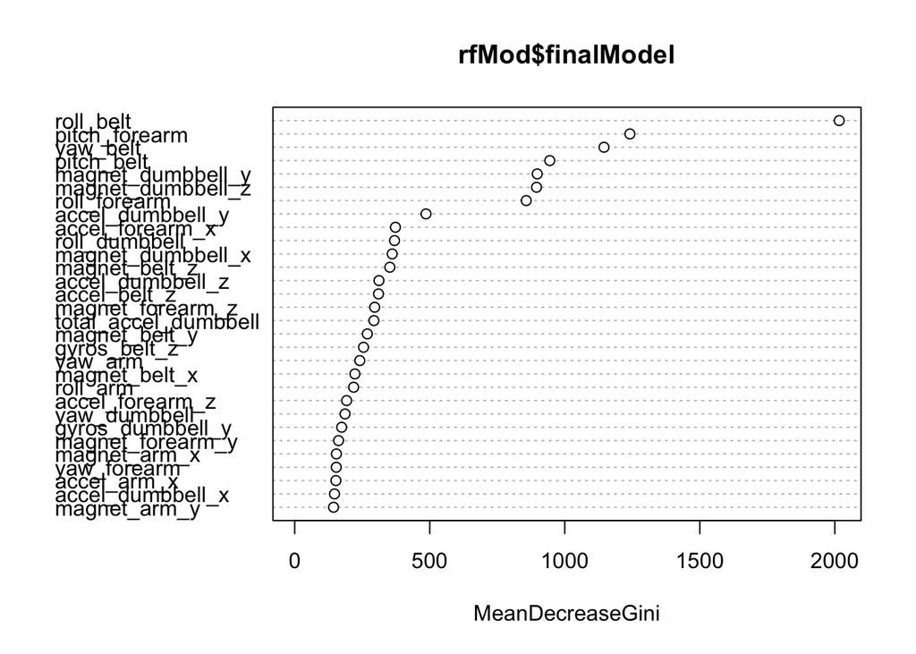

```r
varImpPlot(rfMod$finalModel)
```

```r
tr.data.lodim = tr.data.red[,c("classe","roll_belt","pitch_forearm", "yaw_belt","pitch_belt",
                               "magnet_dumbbell_y","magnet_dumbbell_y","magnet_dumbbell_z")]
```

```r
knnMod = train(classe ~ ., method = "knn", data = tr.data.lodim, trControl = train.control)
```

```r
knnPreds = predict(knnMod, tr.data.lodim)
confusionMatrix(tr.data.red$classe, knnPreds)
```

```
## Confusion Matrix and Statistics
##
##           Reference
## Prediction    A    B    C    D    E
##          A 5302   89   65  109   15
##          B  225 3111  149  154  158
##          C   62  135 3087   87   51
##          D   64   54  143 2929   26
##          E   29  143   66   87 3282
##
## Overall Statistics
##
##                Accuracy : 0.9026
##                  95% CI : (0.8984, 0.9067)
##     No Information Rate : 0.2896
##     P-Value [Acc > NIR] : < 2.2e-16
##
##                   Kappa : 0.8768
##  Mcnemar's Test P-Value : < 2.2e-16
##
## Statistics by Class:
##
##                      Class: A Class: B Class: C Class: D Class: E
## Sensitivity            0.9331   0.8808   0.8795   0.8702   0.9292
## Specificity            0.9801   0.9574   0.9792   0.9823   0.9798
## Pos Pred Value         0.9502   0.8193   0.9021   0.9108   0.9099
## Neg Pred Value         0.9729   0.9734   0.9739   0.9734   0.9844
## Prevalence             0.2896   0.1800   0.1789   0.1715   0.1800
## Detection Rate         0.2702   0.1585   0.1573   0.1493   0.1673
## Detection Prevalence   0.2844   0.1935   0.1744   0.1639   0.1838
## Balanced Accuracy      0.9566   0.9191   0.9293   0.9263   0.9545
```

Just a few seconds to run and about 90% accuracy, not bad at all. The trade-off between execution speed and accuracy is evident. We can plot the error term; however, be wary of the interpretation of the error term in the context of this model (notice Neighbors on the x axis as opposed to the Randomly Selected Predictors which we had with the random forests algorithm)

[figure not shown]

```r
plot(knnMod)
```

## Predicting

To test the model, we first download and load the required test data.

```r
if(!file.exists("pml-testing.csv")) {
        fileURL = "https://d396qusza40orc.cloudfront.net/predmachlearn/pml-testing.csv"
        download.file(fileURL, destfile = "pml-testing.csv", method = "auto")
}
test.data = read.csv("pml-testing.csv")
```

We can now use our random forest model to predict the output to get our results.

```r
testPreds = predict(rfMod, test.data)
testPreds
```

```
##  [1] B A B A A E D B A A B C B A E E A B B B
## Levels: A B C D E
```

We conclude by closing the optimization routine which we initiated earlier.

```r
stopCluster(cluster)
registerDoSEQ()
```